# Practical Machine Learning Course Project

Jerrod Sharpe

Sunday, March 22, 2015

Background

Using devices such as Jawbone Up, Nike FuelBand, and Fitbit it is now possible to collect a large amount of data about personal activity relatively inexpensively. These type of devices are part of the quantified self movement - a group of enthusiasts who take measurements about themselves regularly to improve their health, to find patterns in their behavior, or because they are tech geeks. One thing that people regularly do is quantify how much of a particular activity they do, but they rarely quantify how well they do it. In this project, your goal will be to use data from accelerometers on the belt, forearm, arm, and dumbell of 6 participants. They were asked to perform barbell lifts correctly and incorrectly in 5 different ways. More information is available from the website here: http://groupware.les.inf.puc-rio.br/har (see the section on the Weight Lifting Exercise Dataset).

```r
rm(list=ls())
setwd("~/Coursera/Practical Machine Learning")
fileUrl = "https://d396qusza40orc.cloudfront.net/predmachlearn/pml-training.csv"
fileUrl = "https://d396qusza40orc.cloudfront.net/predmachlearn/pml-testing.csv"
#download.file(fileUrl, destfile= "./pml_training.csv")
#download.file(fileUrl, destfile= "./pml_testing.csv")
library(caret)
library(randomForest)
library(rpart)
library(partykit)
library(C50)

pmltraining = read.csv("pml_training.csv")
pmltesting = read.csv("pml_testing.csv")
```

Question: Can we correctly identify the five different ways participants were asked to perform barbell lifts correctly and incorrectly?

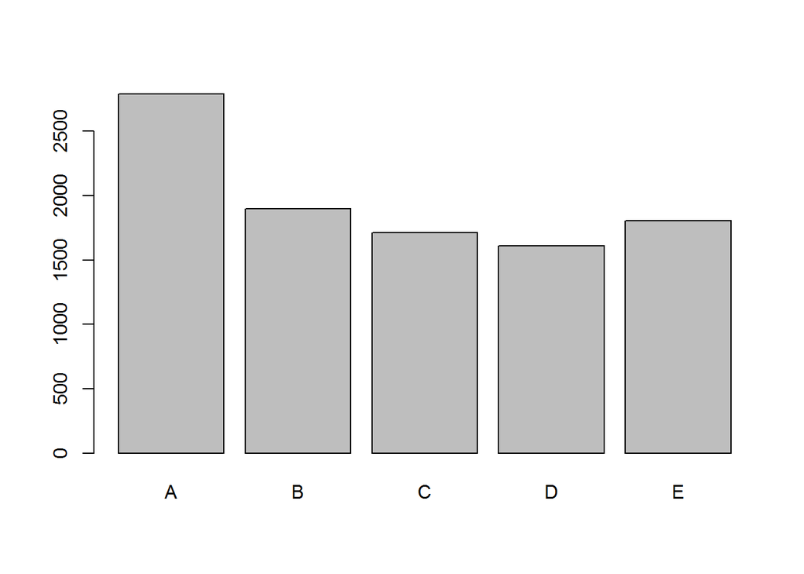

Input Data: Data from accelerometers on the belt, forearm, arm, and dumbell of 6 participant within the study. There are 160 variable in the training data set (including the ‘classe’ the class type ). However, they are number of variables with lots of missing values (both blank and NA). They seem to only have values when the “new window” variable is “yes”. These variables were removed. The first seven columns were removed, “X” to “window num”. The data was split eveningly between training and testing sets.

The distribution of classe type is relatively even, with class A having the most. This indicates that the training set is likely balanced and there is little need to penalize the model for getting class A type wrong versus any of the other class types (see plot).

```r
dim(training)
```

```
## [1] 9812  160
```

```r
training = training[,!sapply(training,function(x) any(is.na(x)))]
training = training[,!sapply(training,function(x) any(x==""))]
dim(training)
```

```
## [1] 9812   60
```

```r
str(training)
```

```
## 'data.frame':    9812 obs. of  60 variables:
##  $ X                   : int  2 3 6 7 12 13 14 17 19 20 ...
##  $ user_name           : Factor w/ 6 levels "adelmo","carlitos",..: 2 2 2 2 2 2 2 2 2 2 ...
##  $ raw_timestamp_part_1: int  1323084231 1323084231 1323084232 1323084232 1323084232 1323084232 1323084232 1323084232 1323084232 1323084232 ...
##  $ raw_timestamp_part_2: int  808298 820366 304277 368296 528316 560359 576390 692324 740353 788335 ...
##  $ cvtd_timestamp      : Factor w/ 20 levels "02/12/2011 13:32",..: 9 9 9 9 9 9 9 9 9 9 ...
##  $ new_window          : Factor w/ 2 levels "no","yes": 1 1 1 1 1 1 1 1 1 1 ...
##  $ num_window          : int  11 11 12 12 12 12 12 12 12 12 ...
##  $ roll_belt           : num  1.41 1.42 1.45 1.42 1.43 1.42 1.42 1.51 1.57 1.59 ...
##  $ pitch_belt          : num  8.07 8.07 8.06 8.09 8.18 8.2 8.21 8.12 8.06 8.07 ...
##  $ yaw_belt            : num  -94.4 -94.4 -94.4 -94.4 -94.4 -94.4 -94.4 -94.4 -94.4 -94.4 ...
##  $ total_accel_belt    : int  3 3 3 3 3 3 3 3 3 3 ...
##  $ gyros_belt_x        : num  0.02 0 0.02 0.02 0.02 0.02 0.02 0 0 0.02 ...
##  $ gyros_belt_y        : num  0 0 0 0 0 0 0 0 0 0 ...
##  $ gyros_belt_z        : num  -0.02 -0.02 -0.02 -0.02 -0.02 0 -0.02 -0.02 -0.02 -0.02 ...
```

[output cut: 46 more lines]

```r
training = training[,-seq(1,7)]
```

Following Max Kuhn’s example (www.edii.uclm.es/~useR-2013/Tutorials/kuhn/user_caret_2up.pdf), I first ran the rpart model with a shallow set of trees on the training set. Then I ran with no restrictions on the depth of trees. The accuracy improved from 37% to 73%.

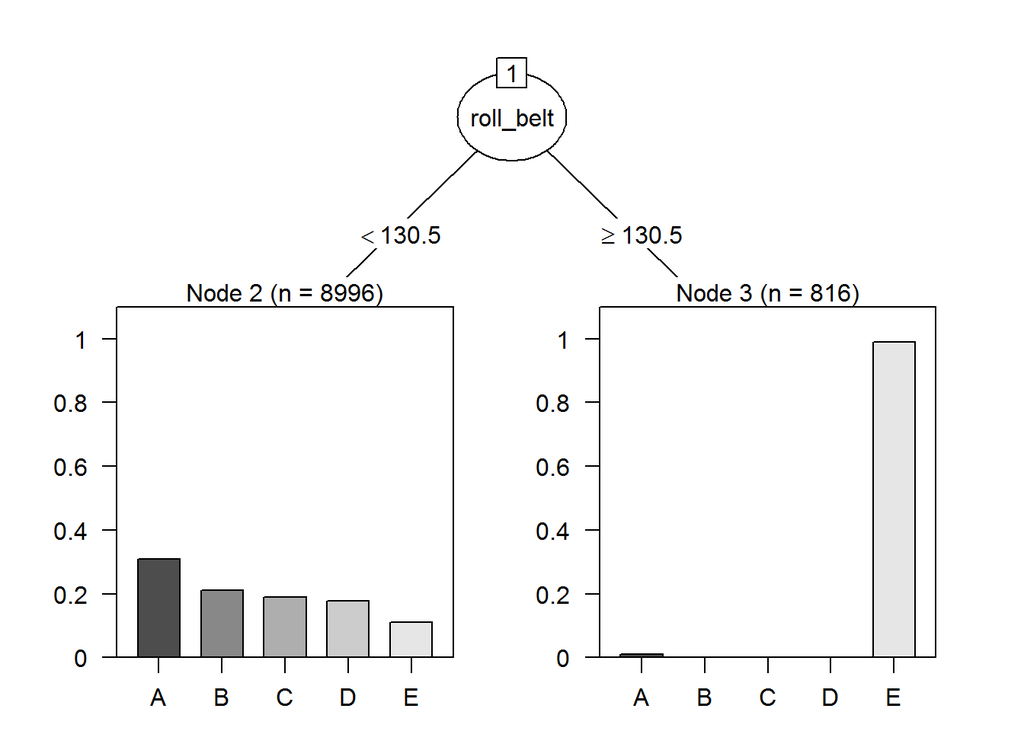

```r
rpart <- rpart(classe ~ ., data = training, method = "class",
               control = rpart.control(maxdepth = 2))
rpart1 <- as.party(rpart)
plot(rpart1)
```

```r
rpartPred<- predict(rpart, testing, type = "class")
confusionMatrix(rpartPred, testing$classe)
```

```
## Confusion Matrix and Statistics
##
##           Reference
## Prediction    A    B    C    D    E
##          A 2785 1898 1711 1608  979
##          B    0    0    0    0    0
##          C    0    0    0    0    0
##          D    0    0    0    0    0
##          E    5    0    0    0  824
##
## Overall Statistics
##
##                Accuracy : 0.3679
##                  95% CI : (0.3583, 0.3775)
##     No Information Rate : 0.2844
##     P-Value [Acc > NIR] : < 2.2e-16
##
##                   Kappa : 0.127
##  Mcnemar's Test P-Value : NA
##
## Statistics by Class:
##
##                      Class: A Class: B Class: C Class: D Class: E
## Sensitivity            0.9982   0.0000   0.0000   0.0000  0.45702
## Specificity            0.1174   1.0000   1.0000   1.0000  0.99938
## Pos Pred Value         0.3101      NaN      NaN      NaN  0.99397
## Neg Pred Value         0.9940   0.8065   0.8256   0.8361  0.89099
## Prevalence             0.2844   0.1935   0.1744   0.1639  0.18379
## Detection Rate         0.2839   0.0000   0.0000   0.0000  0.08400
## Detection Prevalence   0.9155   0.0000   0.0000   0.0000  0.08451
## Balanced Accuracy      0.5578   0.5000   0.5000   0.5000  0.72820
```

```r
rpart2 <- rpart(classe ~ ., data = training, method = "class")
rpartPred2<- predict(rpart2, testing, type = "class")
confusionMatrix(rpartPred2, testing$classe)
```

```
## Confusion Matrix and Statistics
##
##           Reference
## Prediction    A    B    C    D    E
##          A 2547  400  105  269   85
##          B   62 1128  155   70  135
##          C   72  144 1294  250  217
##          D   60  134  115  874   94
##          E   49   92   42  145 1272
##
## Overall Statistics
##
##                Accuracy : 0.7253
##                  95% CI : (0.7163, 0.7341)
##     No Information Rate : 0.2844
##     P-Value [Acc > NIR] : < 2.2e-16
##
##                   Kappa : 0.6497
##  Mcnemar's Test P-Value : < 2.2e-16
##
## Statistics by Class:
##
##                      Class: A Class: B Class: C Class: D Class: E
## Sensitivity            0.9129   0.5943   0.7563  0.54353   0.7055
## Specificity            0.8776   0.9467   0.9157  0.95087   0.9590
## Pos Pred Value         0.7478   0.7277   0.6545  0.68442   0.7950
## Neg Pred Value         0.9621   0.9068   0.9468  0.91398   0.9353
## Prevalence             0.2844   0.1935   0.1744  0.16391   0.1838
## Detection Rate         0.2596   0.1150   0.1319  0.08909   0.1297
## Detection Prevalence   0.3472   0.1580   0.2015  0.13017   0.1631
## Balanced Accuracy      0.8953   0.7705   0.8360  0.74720   0.8323
```

In continuing with Max Kuhn’s examples, I used three repeats of 10-fold cross-validation on the rpart model. It increased the accuracy to 82%.

```r
cvCtrl <- trainControl(method = "repeatedcv", repeats = 3,
                       allowParallel = TRUE,
                       classProbs = TRUE)
set.seed(1)
rpartTune <- train(classe ~ ., data = training, method = "rpart",
                   tuneLength = 30,
                   trControl = cvCtrl)

rpartPred3 <- predict(rpartTune, testing)
confusionMatrix(rpartPred3, testing$classe)
```

```
## Confusion Matrix and Statistics
##
##           Reference
## Prediction    A    B    C    D    E
##          A 2463  190   40   54   39
##          B  113 1385  166   85  116
##          C   50  171 1447   78  102
##          D  115   71   48 1308   93
##          E   49   81   10   83 1453
##
## Overall Statistics
##
##                Accuracy : 0.8212
##                  95% CI : (0.8135, 0.8287)
##     No Information Rate : 0.2844
##     P-Value [Acc > NIR] : < 2.2e-16
##
##                   Kappa : 0.7739
##  Mcnemar's Test P-Value : < 2.2e-16
##
## Statistics by Class:
##
##                      Class: A Class: B Class: C Class: D Class: E
## Sensitivity            0.8828   0.7297   0.8457   0.8134   0.8059
## Specificity            0.9540   0.9393   0.9505   0.9601   0.9721
## Pos Pred Value         0.8841   0.7426   0.7830   0.8000   0.8669
## Neg Pred Value         0.9534   0.9354   0.9668   0.9633   0.9570
## Prevalence             0.2844   0.1935   0.1744   0.1639   0.1838
## Detection Rate         0.2511   0.1412   0.1475   0.1333   0.1481
## Detection Prevalence   0.2840   0.1901   0.1884   0.1667   0.1708
## Balanced Accuracy      0.9184   0.8345   0.8981   0.8868   0.8890
```

Finally, I performed Boosting via C5.0 (follwing Max Kuhn’s example).

```r
cvCtrl <- trainControl(method = "repeatedcv", repeats = 1,
                       number = 3,
                       allowParallel = TRUE,
                       classProbs = TRUE)
grid <- expand.grid(.model = "tree",
                    .trials = c(1:50),
                    .winnow = FALSE)
set.seed(1)
c5Tune <- C5.0(training[,-53], training$classe,
                            control = C5.0Control(),
                            trials = 50,
                            winnow = True,
                            rules=TRUE)
c5TunePred <- predict(c5Tune, testing)
confusionMatrix(c5TunePred, testing$classe)
```

```
## Confusion Matrix and Statistics
##
##           Reference
## Prediction    A    B    C    D    E
##          A 2776    7    0    0    1
##          B   14 1889    6    1    0
##          C    0    2 1697   11    0
##          D    0    0    7 1594    8
##          E    0    0    1    2 1794
##
## Overall Statistics
##
##                Accuracy : 0.9939
##                  95% CI : (0.9921, 0.9953)
##     No Information Rate : 0.2844
##     P-Value [Acc > NIR] : < 2.2e-16
##
##                   Kappa : 0.9923
##  Mcnemar's Test P-Value : NA
##
## Statistics by Class:
##
##                      Class: A Class: B Class: C Class: D Class: E
## Sensitivity            0.9950   0.9953   0.9918   0.9913   0.9950
## Specificity            0.9989   0.9973   0.9984   0.9982   0.9996
## Pos Pred Value         0.9971   0.9890   0.9924   0.9907   0.9983
## Neg Pred Value         0.9980   0.9989   0.9983   0.9983   0.9989
## Prevalence             0.2844   0.1935   0.1744   0.1639   0.1838
## Detection Rate         0.2830   0.1926   0.1730   0.1625   0.1829
## Detection Prevalence   0.2838   0.1947   0.1743   0.1640   0.1832
## Balanced Accuracy      0.9969   0.9963   0.9951   0.9947   0.9973
```

```r
predictions <- as.numeric(predict(c5Tune, testing, type = 'class'))
multiclass.roc(testing$classe, predictions)
```

```
##
## Call:
## multiclass.roc.default(response = testing$classe, predictor = predictions)
##
## Data: predictions with 5 levels of testing$classe: A, B, C, D, E.
## Multi-class area under the curve: 0.9981
```